# AIML_ML_Project_full_code_notebook_final

# Question 3:

**What are the attributes that have a strong correlation with the target attribute (personal loan)?**

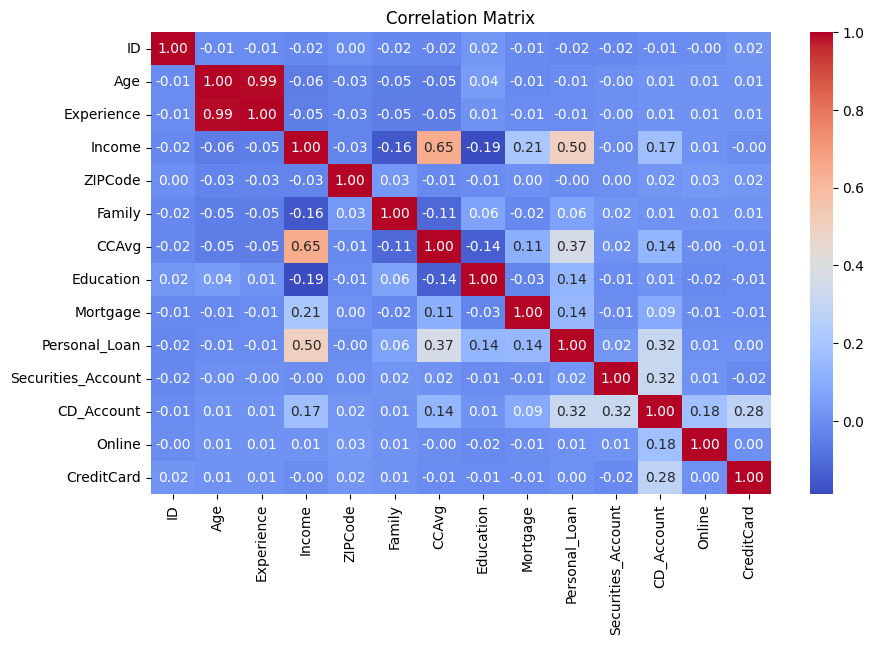

```python
#plot correlation matrix
correlation_matrix = df.corr()
plt.figure(figsize=(10, 6))
sns.heatmap(correlation_matrix, annot=True, cmap='coolwarm', fmt='.2f')
plt.title('Correlation Matrix')
plt.show()
```

# Question 3 Answer:

The attributes **Income** (annual income of the customer in thousand dollars) and **CCAvg** (average spending on credit cards per month in thousand dollars), had the strongest correlation with the target attribute: Personal Loan.

# Question 4:

**How does a customer's interest in purchasing a loan vary with their age?**

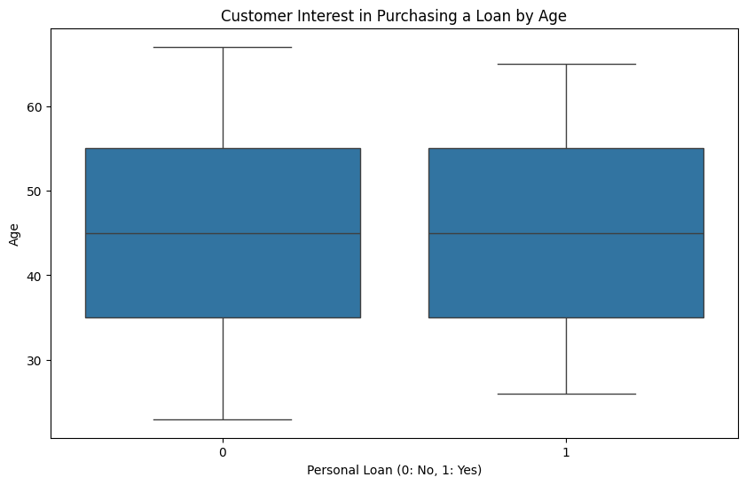

```python
#box plots for personal loan status by age
plt.figure(figsize=(10, 6))
sns.boxplot(x='Personal_Loan', y='Age', data=df)
plt.title('Customer Interest in Purchasing a Loan by Age')
plt.xlabel('Personal Loan (0: No, 1: Yes)')
plt.ylabel('Age')
plt.show()
```

# Question 4 Answer:

As shown in the figure above, the distributions by age for purchasing/not purchasing a loan are very similar, showing that **a customer's interest in purchasing a loan does not vary with their age**. A small note, looking at the max/min whiskers, is that min value for customers who purchase loans is greater than the min value for customers who don't, and the max value for customers who purchase loans is less than the max value for customers who don't.

# Question 5:

**How does a customer's interest in purchasing a loan vary with their education?**

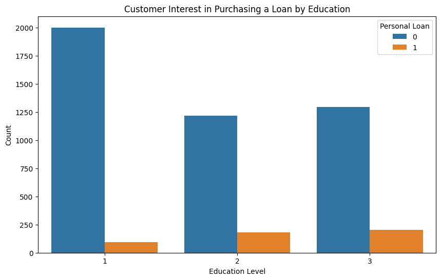

```python
#countplots for personal loan purchase count by education level
plt.figure(figsize=(10, 6))
sns.countplot(x='Education', hue='Personal_Loan', data=df)
plt.title('Customer Interest in Purchasing a Loan by Education')
plt.xlabel('Education Level')
plt.ylabel('Count')
plt.legend(title='Personal Loan', loc='upper right')
plt.show()
```

# Question 5:

As shown in the figure above, **the greater the education level, the greater the interest in purchasing a loan**, since in the figure above, as education level increases, loan purchases increase.

## Data Preprocessing

- Missing value treatment
- Feature engineering (if needed)
- Outlier detection and treatment (if needed)
- Preparing data for modeling
- Any other preprocessing steps (if needed)

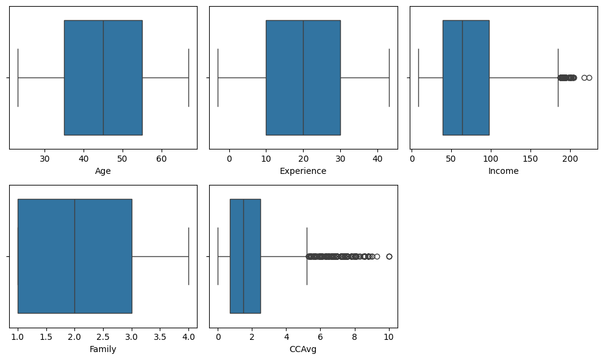

```python
#There are no missing values

#check for outliers below using boxplot
columns = ['Age', 'Experience', 'Income', 'Family', 'CCAvg']
plt.figure(figsize=(10, 6))
for i, column in enumerate(columns, 1):
    plt.subplot(2, 3, i)
    sns.boxplot(x=df[column])
plt.tight_layout()
plt.show()
```

- There are no missing values, as discovered in the Data Overview section.
- Outliers appear in CCAVg (average credit card spend) and Income. However, I don't think we need to deal with them, since it is reasonable to have outliers in income and credit card spend.

```python
#use pyzipcode library to convert nunmerical values in zip column to cateogrical values (strings of the corresponding locations)

#zipcode databse from pyzipcode lib
zcdb = ZipCodeDatabase()

#function to convert zipcodes to corresponding location string
def convert_zipcodes(zipcode):
  if zipcode in zcdb:
      location = zcdb[zipcode]
      #location is a ZipCode object with .city and .state members
      return f'{location.city}, {location.state}'
  else:
      return 'Unknown'

#make a location column that holds the string value of the location of the zipcode, e.g. 'Pasadena, CA'
df['Location'] = df['ZIPCode'].apply(lambda zipcode: convert_zipcodes(zipcode))
#drop original zip code column
df = df.drop(columns=['ZIPCode'], axis=1)

df.head()
```

|  | ID | Age | Experience | Income | Family | CCAvg | Education | Mortgage | Personal_Loan | Securities_Account | CD_Account | Online | CreditCard | Location |
| --- | --- | --- | --- | --- | --- | --- | --- | --- | --- | --- | --- | --- | --- | --- |
| 0 | 1 | 25 | 1 | 49 | 4 | 1.6 | 1 | 0 | 0 | 1 | 0 | 0 | 0 | Pasadena, CA |
| 1 | 2 | 45 | 19 | 34 | 3 | 1.5 | 1 | 0 | 0 | 1 | 0 | 0 | 0 | Los Angeles, CA |
| 2 | 3 | 39 | 15 | 11 | 1 | 1.0 | 1 | 0 | 0 | 0 | 0 | 0 | 0 | Berkeley, CA |
| 3 | 4 | 35 | 9 | 100 | 1 | 2.7 | 2 | 0 | 0 | 0 | 0 | 0 | 0 | San Francisco, CA |
| 4 | 5 | 35 | 8 | 45 | 4 | 1.0 | 2 | 0 | 0 | 0 | 0 | 0 | 1 | Northridge, CA |

```python
df.info()
```

```
<class 'pandas.core.frame.DataFrame'>
RangeIndex: 5000 entries, 0 to 4999
Data columns (total 14 columns):
 #   Column              Non-Null Count  Dtype
---  ------              --------------  -----
 0   ID                  5000 non-null   int64
 1   Age                 5000 non-null   int64
 2   Experience          5000 non-null   int64
 3   Income              5000 non-null   int64
 4   Family              5000 non-null   int64
 5   CCAvg               5000 non-null   float64
 6   Education           5000 non-null   int64
 7   Mortgage            5000 non-null   int64
 8   Personal_Loan       5000 non-null   int64
 9   Securities_Account  5000 non-null   int64
 10  CD_Account          5000 non-null   int64
 11  Online              5000 non-null   int64
 12  CreditCard          5000 non-null   int64
 13  Location            5000 non-null   object
dtypes: float64(1), int64(12), object(1)
memory usage: 547.0+ KB
```

```python
#drop ID column since it only contains unique values
df = df.drop(['ID'], axis=1)
#decided to drop the location column for model simplicity
df = df.drop(['Location'], axis=1)
```

Even though I did the work to map zip codes to locations, I'm deciding to drop the location column alltogether, since it complicates the model, and the correlation matrix showed that it has no effect on Personal Loan purchases.

```python
#seperate independent and dependent variables
X = df.drop(['Personal_Loan'], axis=1)
y = df["Personal_Loan"]
```

```python
#one hot encoding not needed since location column is dropped
# X = pd.get_dummies(df, columns=['Location'], drop_first=True, dtype=int)

X.head()
```

|  | Age | Experience | Income | Family | CCAvg | Education | Mortgage | Securities_Account | CD_Account | Online | CreditCard |
| --- | --- | --- | --- | --- | --- | --- | --- | --- | --- | --- | --- |
| 0 | 25 | 1 | 49 | 4 | 1.6 | 1 | 0 | 1 | 0 | 0 | 0 |
| 1 | 45 | 19 | 34 | 3 | 1.5 | 1 | 0 | 1 | 0 | 0 | 0 |
| 2 | 39 | 15 | 11 | 1 | 1.0 | 1 | 0 | 0 | 0 | 0 | 0 |
| 3 | 35 | 9 | 100 | 1 | 2.7 | 2 | 0 | 0 | 0 | 0 | 0 |
| 4 | 35 | 8 | 45 | 4 | 1.0 | 2 | 0 | 0 | 0 | 0 | 1 |

```python
#display target attribute
y.head()
```

|  | Personal_Loan |
| --- | --- |
| 0 | 0 |
| 1 | 0 |
| 2 | 0 |
| 3 | 0 |
| 4 | 0 |

**dtype:** int64

```python
#Split the data into training and testing sets
X_train, X_test, y_train, y_test = train_test_split(X, y, test_size=0.20, stratify=y, random_state=42)
```

```python
print("Shape of Training set : ", X_train.shape)
print("Shape of Test set : ", X_test.shape)
print("Percentage of classes in Training set:")
print(y_train.value_counts(normalize=True))
print("Percentage of classes in Test set:")
print(y_test.value_counts(normalize=True))
```

```
Shape of Training set :  (4000, 11)
Shape of Test set :  (1000, 11)
Percentage of classes in Training set:
Personal_Loan
0    0.904
1    0.096
Name: proportion, dtype: float64
Percentage of classes in Test set:
Personal_Loan
0    0.904
1    0.096
Name: proportion, dtype: float64
```

## Model Building

### Model Evaluation Criterion

```python
#function to compute different metrics to check performance of classification model
def model_performance_classification(model, predictors, target):
    """
    Function to compute different metrics to check classification model performance

    model: classifier
    predictors: independent variables
    target: dependent variable
    """

    # predicting using the independent variables
    pred = model.predict(predictors)

    acc = accuracy_score(target, pred)  # to compute Accuracy
    recall = recall_score(target, pred)  # to compute Recall
    precision = precision_score(target, pred)  # to compute Precision
    f1 = f1_score(target, pred)  # to compute F1-score

    # creating a dataframe of metrics
    df_perf = pd.DataFrame(
        {"Accuracy": acc, "Recall": recall, "Precision": precision, "F1": f1,},
        index=[0],
    )

    return df_perf
```

```python
#function to plot confusion matrix for model
def plot_confusion_matrix(model, predictors, target):
    """
    To plot the confusion_matrix with percentages

    model: classifier
    predictors: independent variables
    target: dependent variable
    """
    # Predict the target values using the provided model and predictors
    y_pred = model.predict(predictors)

    # Compute the confusion matrix comparing the true target values with the predicted values
    cm = confusion_matrix(target, y_pred)

    # Create labels for each cell in the confusion matrix with both count and percentage
    labels = np.asarray(
        [
            ["{0:0.0f}".format(item) + "\n{0:.2%}".format(item / cm.flatten().sum())]
            for item in cm.flatten()
        ]
    ).reshape(2, 2)    # reshaping to a matrix

    #Set figure size for the plot
    plt.figure(figsize=(6, 4))

    # Plot the confusion matrix as a heatmap with the labels
    sns.heatmap(cm, annot=labels, fmt="")

    #Add label to the y-axis
    plt.ylabel("True label")

    #Add label to the x-axis
    plt.xlabel("Predicted label")
```

### Model Building

```python
#create an instance of the decision tree model
dtree = DecisionTreeClassifier(random_state=42)

#fitting model to training data
dtree.fit(X_train, y_train)
```

```
DecisionTreeClassifier(random_state=42)
```

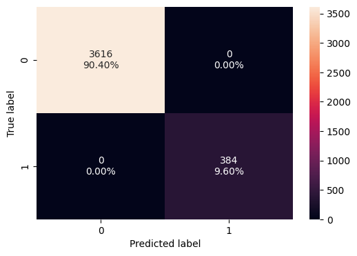

```python
plot_confusion_matrix(dtree, X_train, y_train)
```

```python
dtree_train_perf = model_performance_classification(
    dtree, X_train, y_train
)
dtree_train_perf
```

|  | Accuracy | Recall | Precision | F1 |
| --- | --- | --- | --- | --- |
| 0 | 1.0 | 1.0 | 1.0 | 1.0 |

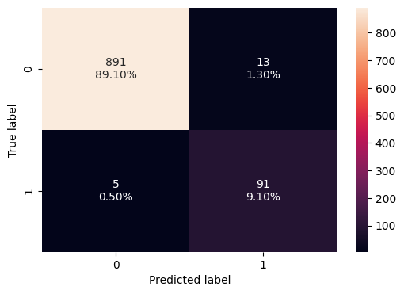

```python
plot_confusion_matrix(dtree, X_test, y_test)
```

```python
dtree_test_perf = model_performance_classification(
    dtree, X_test, y_test
)
dtree_test_perf
```

|  | Accuracy | Recall | Precision | F1 |
| --- | --- | --- | --- | --- |
| 0 | 0.982 | 0.947917 | 0.875 | 0.91 |

The unpruned model performed perfectly on the train data, and almost just as well on the test data, with a 0.91 F1 score.

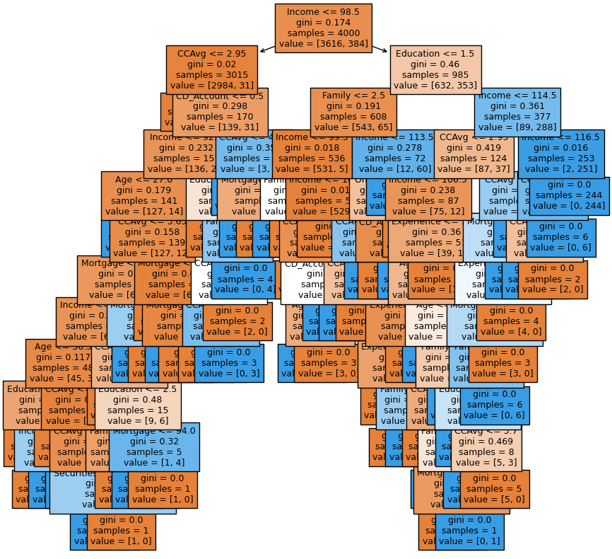

```python
# list of feature names in X_train
feature_names = list(X_train.columns)

# set the figure size for the plot
plt.figure(figsize=(10, 10))

# plotting the decision tree
out = tree.plot_tree(
    dtree,                         # decision tree classifier model
    feature_names=feature_names,    # list of feature names (columns) in the dataset
    filled=True,                    # fill the nodes with colors based on class
    fontsize=9,                     # font size for the node text
    node_ids=False,                 # do not show the ID of each node
    class_names=None,               # whether or not to display class names
)

# add arrows to the decision tree splits if they are missing
for o in out:
    arrow = o.arrow_patch
    if arrow is not None:
        arrow.set_edgecolor("black")
        arrow.set_linewidth(1)

# displaying the plot
plt.show()
```

As shown above, this is a pretty complex tree.

```python
#print the rules of the unpruned tree
print(tree.export_text(dtree, feature_names=feature_names, show_weights=True))
```

```
|--- Income <= 98.50
|   |--- CCAvg <= 2.95
|   |   |--- weights: [2845.00, 0.00] class: 0
|   |--- CCAvg >  2.95
|   |   |--- CD_Account <= 0.50
|   |   |   |--- Income <= 92.50
|   |   |   |   |--- Age <= 27.00
|   |   |   |   |   |--- weights: [0.00, 2.00] class: 1
|   |   |   |   |--- Age >  27.00
|   |   |   |   |   |--- CCAvg <= 3.65
|   |   |   |   |   |   |--- Mortgage <= 216.50
|   |   |   |   |   |   |   |--- Income <= 82.50
|   |   |   |   |   |   |   |   |--- Age <= 36.50
|   |   |   |   |   |   |   |   |   |--- Education <= 1.50
|   |   |   |   |   |   |   |   |   |   |--- weights: [6.00, 0.00] class: 0
|   |   |   |   |   |   |   |   |   |--- Education >  1.50
|   |   |   |   |   |   |   |   |   |   |--- Income <= 63.50
|   |   |   |   |   |   |   |   |   |   |   |--- weights: [1.00, 0.00] class: 0
|   |   |   |   |   |   |   |   |   |   |--- Income >  63.50
|   |   |   |   |   |   |   |   |   |   |   |--- weights: [0.00, 2.00] class: 1
|   |   |   |   |   |   |   |   |--- Age >  36.50
|   |   |   |   |   |   |   |   |   |--- CCAvg <= 3.35
|   |   |   |   |   |   |   |   |   |   |--- weights: [29.00, 0.00] class: 0
|   |   |   |   |   |   |   |   |   |--- CCAvg >  3.35
|   |   |   |   |   |   |   |   |   |   |--- CCAvg <= 3.55
|   |   |   |   |   |   |   |   |   |   |   |--- weights: [0.00, 1.00] class: 1
|   |   |   |   |   |   |   |   |   |   |--- CCAvg >  3.55
|   |   |   |   |   |   |   |   |   |   |   |--- weights: [9.00, 0.00] class: 0
|   |   |   |   |   |   |   |--- Income >  82.50
|   |   |   |   |   |   |   |   |--- CCAvg <= 3.05
|   |   |   |   |   |   |   |   |   |--- weights: [6.00, 0.00] class: 0
|   |   |   |   |   |   |   |   |--- CCAvg >  3.05
|   |   |   |   |   |   |   |   |   |--- Education <= 2.50
|   |   |   |   |   |   |   |   |   |   |--- Family <= 1.50
|   |   |   |   |   |   |   |   |   |   |   |--- truncated branch of depth 2
|   |   |   |   |   |   |   |   |   |   |--- Family >  1.50
|   |   |   |   |   |   |   |   |   |   |   |--- weights: [7.00, 0.00] class: 0
|   |   |   |   |   |   |   |   |   |--- Education >  2.50
|   |   |   |   |   |   |   |   |   |   |--- Mortgage <= 94.00
|   |   |   |   |   |   |   |   |   |   |   |--- weights: [0.00, 4.00] class: 1
```

[output cut: 129 more lines]

```
|   |   |   |   |   |--- Mortgage >  265.50
|   |   |   |   |   |   |--- weights: [0.00, 5.00] class: 1
|   |   |   |   |--- CCAvg >  4.65
|   |   |   |   |   |--- weights: [0.00, 7.00] class: 1
|   |   |--- Income >  114.50
|   |   |   |--- Income <= 116.50
|   |   |   |   |--- CCAvg <= 1.10
|   |   |   |   |   |--- CCAvg <= 0.65
|   |   |   |   |   |   |--- weights: [0.00, 1.00] class: 1
|   |   |   |   |   |--- CCAvg >  0.65
|   |   |   |   |   |   |--- weights: [2.00, 0.00] class: 0
|   |   |   |   |--- CCAvg >  1.10
|   |   |   |   |   |--- weights: [0.00, 6.00] class: 1
|   |   |   |--- Income >  116.50
|   |   |   |   |--- weights: [0.00, 244.00] class: 1
```

## Model Performance Improvement

# Pre-Pruning

```python
# Define the parameters of the tree to iterate over
max_depth_values = np.arange(2, 7, 2)
max_leaf_nodes_values = [50, 75, 150, 250]
min_samples_split_values = [10, 30, 50, 70]

# Initialize variables to store the best model and its performance
best_estimator = None
best_score_diff = float('inf')
best_test_score = 0.0

# Iterate over all combinations of the specified parameter values
for max_depth in max_depth_values:
    for max_leaf_nodes in max_leaf_nodes_values:
        for min_samples_split in min_samples_split_values:

            # Initialize the tree with the current set of parameters
            estimator = DecisionTreeClassifier(
                max_depth=max_depth,
                max_leaf_nodes=max_leaf_nodes,
                min_samples_split=min_samples_split,
                class_weight='balanced',
                random_state=42
            )

            # Fit the model to the training data
            estimator.fit(X_train, y_train)

            # Make predictions on the training and test sets
            y_train_pred = estimator.predict(X_train)
            y_test_pred = estimator.predict(X_test)

            # Calculate recall scores for training and test sets
            train_recall_score = recall_score(y_train, y_train_pred)
            test_recall_score = recall_score(y_test, y_test_pred)

            # Calculate the absolute difference between training and test recall scores
            score_diff = abs(train_recall_score - test_recall_score)

            # Update the best estimator and best score if the current one has a smaller score difference
            if (score_diff < best_score_diff) & (test_recall_score > best_test_score):
                best_score_diff = score_diff
                best_test_score = test_recall_score
                best_estimator = estimator

# Print the best parameters
print("Best parameters found:")
print(f"Max depth: {best_estimator.max_depth}")
print(f"Max leaf nodes: {best_estimator.max_leaf_nodes}")
print(f"Min samples split: {best_estimator.min_samples_split}")
print(f"Best test recall score: {best_test_score}")
```

```
Best parameters found:
Max depth: 2
Max leaf nodes: 50
Min samples split: 10
Best test recall score: 1.0
```

```python
#creating an instance of the best model
dtree2 = best_estimator

#fitting the best model to the training data
dtree2.fit(X_train, y_train)
```

```
DecisionTreeClassifier(class_weight='balanced', max_depth=2, max_leaf_nodes=50,
                       min_samples_split=10, random_state=42)
```

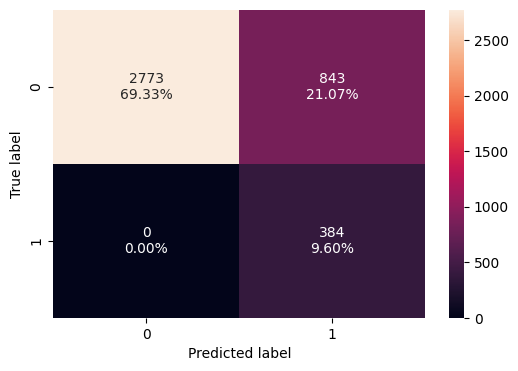

```python
plot_confusion_matrix(dtree2, X_train, y_train)
```

```python
dtree2_train_perf = model_performance_classification(
    dtree2, X_train, y_train
)
dtree2_train_perf
```

|  | Accuracy | Recall | Precision | F1 |
| --- | --- | --- | --- | --- |
| 0 | 0.78925 | 1.0 | 0.312958 | 0.476723 |

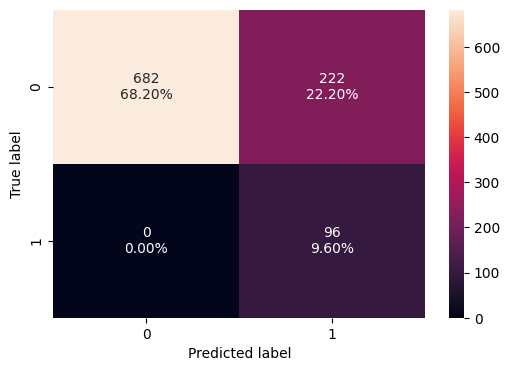

```python
plot_confusion_matrix(dtree2, X_test, y_test)
```

```python
dtree2_test_perf = model_performance_classification(
    dtree2, X_test, y_test
)
dtree2_test_perf
```

|  | Accuracy | Recall | Precision | F1 |
| --- | --- | --- | --- | --- |
| 0 | 0.778 | 1.0 | 0.301887 | 0.463768 |

The F1 scores of the pre-pruned model on both the test and train datasets were very similar, showing a generalized performance. However, the precision scores were low, indicating a high number of false positive predictions. The overall F1 Score is low, indicating poor performance by the pre-pruned model.

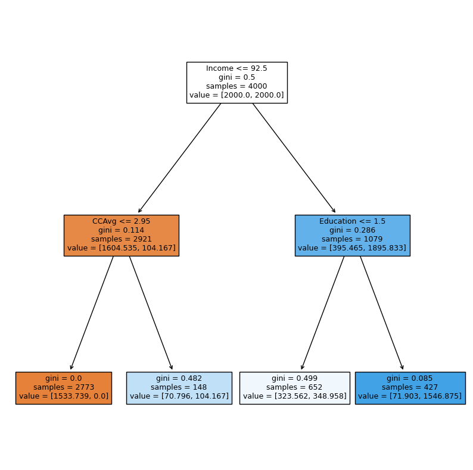

```python
# list of feature names in X_train
feature_names = list(X_train.columns)

# set the figure size for the plot
plt.figure(figsize=(10, 10))

# plotting the decision tree
out = tree.plot_tree(
    dtree2,                         # decision tree classifier model
    feature_names=feature_names,    # list of feature names (columns) in the dataset
    filled=True,                    # fill the nodes with colors based on class
    fontsize=9,                     # font size for the node text
    node_ids=False,                 # do not show the ID of each node
    class_names=None,               # whether or not to display class names
)

# add arrows to the decision tree splits if they are missing
for o in out:
    arrow = o.arrow_patch
    if arrow is not None:
        arrow.set_edgecolor("black")
        arrow.set_linewidth(1)

# displaying the plot
plt.show()
```

As shown, this pre-pruned tree is much less complex, and the rules are much clearer. The model is using just Income, CCAvg, and Education to determine loan purchase probability.

```python
#printing a text report showing the rules of pre-pruned decision tree
print(
    tree.export_text(
        dtree2,
        feature_names=feature_names,    #specify feature names
        show_weights=True    #specify whether or not to show the weights associated with the model
    )
)
```

```
|--- Income <= 92.50
|   |--- CCAvg <= 2.95
|   |   |--- weights: [1533.74, 0.00] class: 0
|   |--- CCAvg >  2.95
|   |   |--- weights: [70.80, 104.17] class: 1
|--- Income >  92.50
|   |--- Education <= 1.50
|   |   |--- weights: [323.56, 348.96] class: 1
|   |--- Education >  1.50
|   |   |--- weights: [71.90, 1546.87] class: 1
```

# Post-Pruning

```python
# Create an instance of the decision tree model
clf = DecisionTreeClassifier(random_state=42)

# Compute the cost complexity pruning path for the model using the training data
path = clf.cost_complexity_pruning_path(X_train, y_train)

# Extract the array of effective alphas from the pruning path
ccp_alphas = abs(path.ccp_alphas)

# Extract the array of total impurities at each alpha along the pruning path
impurities = path.impurities
```

```python
pd.DataFrame(path)
```

|  | ccp_alphas | impurities |
| --- | --- | --- |
| 0 | 0.000000 | 0.000000 |
| 1 | 0.000244 | 0.000487 |
| 2 | 0.000246 | 0.000980 |
| 3 | 0.000296 | 0.001869 |
| 4 | 0.000306 | 0.002788 |
| 5 | 0.000331 | 0.003780 |
| 6 | 0.000333 | 0.004113 |
| 7 | 0.000333 | 0.004446 |
| 8 | 0.000333 | 0.004780 |
| 9 | 0.000350 | 0.005830 |
| 10 | 0.000373 | 0.007321 |
| 11 | 0.000375 | 0.007696 |
| 12 | 0.000381 | 0.008077 |
| 13 | 0.000400 | 0.008477 |
| 14 | 0.000417 | 0.008894 |
| 15 | 0.000419 | 0.011410 |
| 16 | 0.000455 | 0.011865 |
| 17 | 0.000493 | 0.012850 |
| 18 | 0.000542 | 0.013934 |
| 19 | 0.000550 | 0.016133 |
| 20 | 0.000579 | 0.020187 |
| 21 | 0.000584 | 0.020771 |
| 22 | 0.000779 | 0.021550 |
| 23 | 0.000823 | 0.022373 |
| 24 | 0.000831 | 0.023204 |
| 25 | 0.000870 | 0.024945 |
| 26 | 0.002424 | 0.027369 |
| 27 | 0.002667 | 0.030036 |
| 28 | 0.003000 | 0.033036 |
| 29 | 0.003753 | 0.036789 |
| 30 | 0.020023 | 0.056812 |
| 31 | 0.021549 | 0.078361 |
| 32 | 0.047604 | 0.173568 |

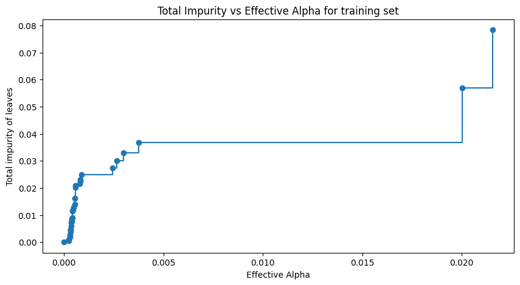

```python
# Create a figure
fig, ax = plt.subplots(figsize=(10, 5))

# Plot the total impurities versus effective alphas, excluding the last value,
# using markers at each data point and connecting them with steps
ax.plot(ccp_alphas[:-1], impurities[:-1], marker="o", drawstyle="steps-post")

# Set the x-axis label
ax.set_xlabel("Effective Alpha")

# Set the y-axis label
ax.set_ylabel("Total impurity of leaves")

# Set the title of the plot
ax.set_title("Total Impurity vs Effective Alpha for training set");
```

```python
#Train the decision tree using the effective alphas

# Initialize an empty list to store the decision tree classifiers
clfs = []

# Iterate over each ccp_alpha value extracted from cost complexity pruning path
for ccp_alpha in ccp_alphas:
    # Create an instance of the DecisionTreeClassifier
    clf = DecisionTreeClassifier(ccp_alpha=ccp_alpha, random_state=42)

    # Fit the classifier to the training data
    clf.fit(X_train, y_train)

    # Append the trained classifier to the list
    clfs.append(clf)

# Print the number of nodes in the last tree along with its ccp_alpha value
print(
    "Number of nodes in the last tree is {} with ccp_alpha {}".format(
        clfs[-1].tree_.node_count, ccp_alphas[-1]
    )
)
```

```
Number of nodes in the last tree is 1 with ccp_alpha 0.04760359071815694
```

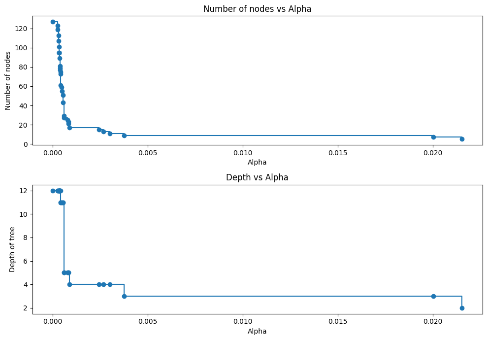

```python
# Remove the last classifier and corresponding ccp_alpha value from the lists
clfs = clfs[:-1]
ccp_alphas = ccp_alphas[:-1]

# Extract the number of nodes in each tree classifier
node_counts = [clf.tree_.node_count for clf in clfs]

# Extract the maximum depth of each tree classifier
depth = [clf.tree_.max_depth for clf in clfs]

# Create a figure and a set of subplots
fig, ax = plt.subplots(2, 1, figsize=(10, 7))

# Plot the number of nodes versus ccp_alphas on the first subplot
ax[0].plot(ccp_alphas, node_counts, marker="o", drawstyle="steps-post")
ax[0].set_xlabel("Alpha")
ax[0].set_ylabel("Number of nodes")
ax[0].set_title("Number of nodes vs Alpha")

# Plot the depth of tree versus ccp_alphas on the second subplot
ax[1].plot(ccp_alphas, depth, marker="o", drawstyle="steps-post")
ax[1].set_xlabel("Alpha")
ax[1].set_ylabel("Depth of tree")
ax[1].set_title("Depth vs Alpha")

# Adjust the layout of the subplots to avoid overlap
fig.tight_layout()
```

```python
train_f1_scores = []  # Initialize an empty list to store F1 scores for training set for each decision tree classifier

# Iterate through each decision tree classifier in 'clfs'
for clf in clfs:
    # Predict labels for the training set using the current decision tree classifier
    pred_train = clf.predict(X_train)

    # Calculate the F1 score for the training set predictions compared to true labels
    f1_train = f1_score(y_train, pred_train)

    # Append the calculated F1 score to the train_f1_scores list
    train_f1_scores.append(f1_train)
```

```python
test_f1_scores = []  # Initialize an empty list to store F1 scores for test set for each decision tree classifier

# Iterate through each decision tree classifier in 'clfs'
for clf in clfs:
    # Predict labels for the test set using the current decision tree classifier
    pred_test = clf.predict(X_test)

    # Calculate the F1 score for the test set predictions compared to true labels
    f1_test = f1_score(y_test, pred_test)

    # Append the calculated F1 score to the test_f1_scores list
    test_f1_scores.append(f1_test)
```

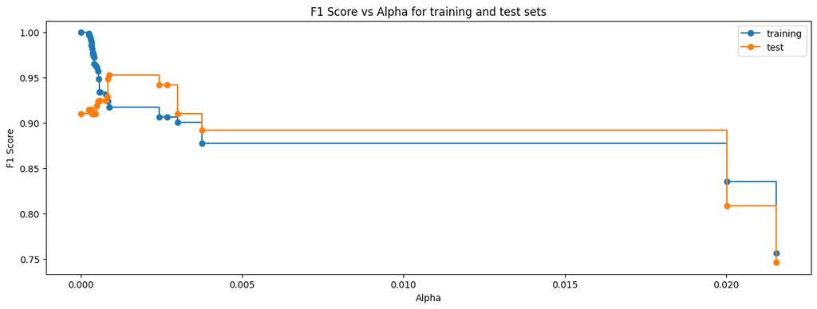

```python
# Create a figure
fig, ax = plt.subplots(figsize=(15, 5))
ax.set_xlabel("Alpha")  # Set the label for the x-axis
ax.set_ylabel("F1 Score")  # Set the label for the y-axis
ax.set_title("F1 Score vs Alpha for training and test sets")  # Set the title of the plot

# Plot the training F1 scores against alpha, using circles as markers and steps-post style
ax.plot(ccp_alphas, train_f1_scores, marker="o", label="training", drawstyle="steps-post")

# Plot the testing F1 scores against alpha, using circles as markers and steps-post style
ax.plot(ccp_alphas, test_f1_scores, marker="o", label="test", drawstyle="steps-post")

ax.legend();  # Add a legend to the plot
```

```python
#creating the model where we get highest test F1 score
index_best_model = np.argmax(test_f1_scores)

#selecting the decision tree model corresponding to the highest test score
dtree3 = clfs[index_best_model]
print(dtree3)
```

```
DecisionTreeClassifier(ccp_alpha=0.0008702884311333967, random_state=42)
```

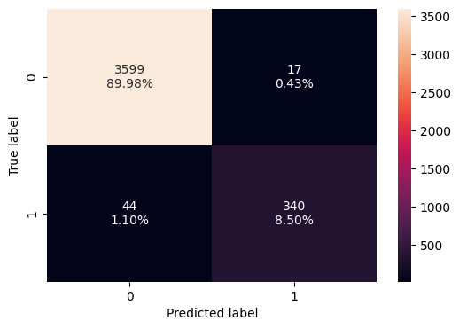

```python
plot_confusion_matrix(dtree3, X_train, y_train)
```

```python
dtree3_train_perf = model_performance_classification(
    dtree3, X_train, y_train
)
dtree3_train_perf
```

|  | Accuracy | Recall | Precision | F1 |
| --- | --- | --- | --- | --- |
| 0 | 0.98475 | 0.885417 | 0.952381 | 0.917679 |

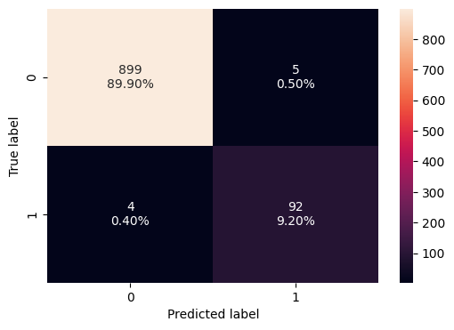

```python
plot_confusion_matrix(dtree3, X_test, y_test)
```

```python
dtree3_test_perf = model_performance_classification(
    dtree3, X_test, y_test
)
dtree3_test_perf
```

|  | Accuracy | Recall | Precision | F1 |
| --- | --- | --- | --- | --- |
| 0 | 0.991 | 0.958333 | 0.948454 | 0.953368 |

The post-pruned model performed even better on the test dataset (0.95 F1 score) than on the train dataset (0.92 F1 Score).

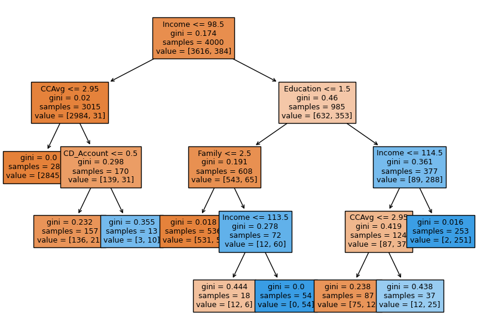

```python
# list of feature names in X_train
feature_names = list(X_train.columns)

# set the figure size for the plot
plt.figure(figsize=(10, 7))

# plotting the decision tree
out = tree.plot_tree(
    dtree3,                         # decision tree classifier model
    feature_names=feature_names,    # list of feature names (columns) in the dataset
    filled=True,                    # fill the nodes with colors based on class
    fontsize=9,                     # font size for the node text
    node_ids=False,                 # do not show the ID of each node
    class_names=None,               # whether or not to display class names
)

# add arrows to the decision tree splits if they are missing
for o in out:
    arrow = o.arrow_patch
    if arrow is not None:
        arrow.set_edgecolor("black")    # set arrow color to black
        arrow.set_linewidth(1)          # set arrow linewidth to 1

# displaying the plot
plt.show()
```

This post-pruned model is simpler than the unpruned model, but more complex than the pre-pruned model, using two more attributes to make decisions. This model uses Income, Education, CCAvg, CD_Account, and Family size to make decisions.

```python
#printing a text report showing the rules of the post-pruned decision tree
print(
    tree.export_text(
        dtree3,
        feature_names=feature_names,
        show_weights=True
    )
)
```

```
|--- Income <= 98.50
|   |--- CCAvg <= 2.95
|   |   |--- weights: [2845.00, 0.00] class: 0
|   |--- CCAvg >  2.95
|   |   |--- CD_Account <= 0.50
|   |   |   |--- weights: [136.00, 21.00] class: 0
|   |   |--- CD_Account >  0.50
|   |   |   |--- weights: [3.00, 10.00] class: 1
|--- Income >  98.50
|   |--- Education <= 1.50
|   |   |--- Family <= 2.50
|   |   |   |--- weights: [531.00, 5.00] class: 0
|   |   |--- Family >  2.50
|   |   |   |--- Income <= 113.50
|   |   |   |   |--- weights: [12.00, 6.00] class: 0
|   |   |   |--- Income >  113.50
|   |   |   |   |--- weights: [0.00, 54.00] class: 1
|   |--- Education >  1.50
|   |   |--- Income <= 114.50
|   |   |   |--- CCAvg <= 2.95
|   |   |   |   |--- weights: [75.00, 12.00] class: 0
|   |   |   |--- CCAvg >  2.95
|   |   |   |   |--- weights: [12.00, 25.00] class: 1
|   |   |--- Income >  114.50
|   |   |   |--- weights: [2.00, 251.00] class: 1
```

## Model Performance Comparison and Final Model Selection

```python
# training performance comparison

models_train_comp_df = pd.concat(
    [
        dtree_train_perf.T, #unpruned
        dtree2_train_perf.T, #pre-pruned
        dtree3_train_perf.T, #post-pruned
    ],
    axis=1,
)
models_train_comp_df.columns = [
    "Decision Tree (default)",
    "Decision Tree (Pre-Pruned)",
    "Decision Tree (Post-Pruned)",
]
print("Training performance comparison:")
models_train_comp_df
```

```
Training performance comparison:
```

|  | Decision Tree (default) | Decision Tree (Pre-Pruned) | Decision Tree (Post-Pruned) |
| --- | --- | --- | --- |
| Accuracy | 1.0 | 0.789250 | 0.984750 |
| Recall | 1.0 | 1.000000 | 0.885417 |
| Precision | 1.0 | 0.312958 | 0.952381 |
| F1 | 1.0 | 0.476723 | 0.917679 |

```python
# testing performance comparison

models_test_comp_df = pd.concat(
    [
        dtree_test_perf.T,
        dtree2_test_perf.T,
        dtree3_test_perf.T,
    ],
    axis=1,
)
models_test_comp_df.columns = [
    "Decision Tree (default)",
    "Decision Tree (Pre-Pruned)",
    "Decision Tree (Post-Pruned)",
]
print("Test set performance comparison:")
models_test_comp_df
```

```
Test set performance comparison:
```

|  | Decision Tree (default) | Decision Tree (Pre-Pruned) | Decision Tree (Post-Pruned) |
| --- | --- | --- | --- |
| Accuracy | 0.982000 | 0.778000 | 0.991000 |
| Recall | 0.947917 | 1.000000 | 0.958333 |
| Precision | 0.875000 | 0.301887 | 0.948454 |
| F1 | 0.910000 | 0.463768 | 0.953368 |

**Feature Importance**

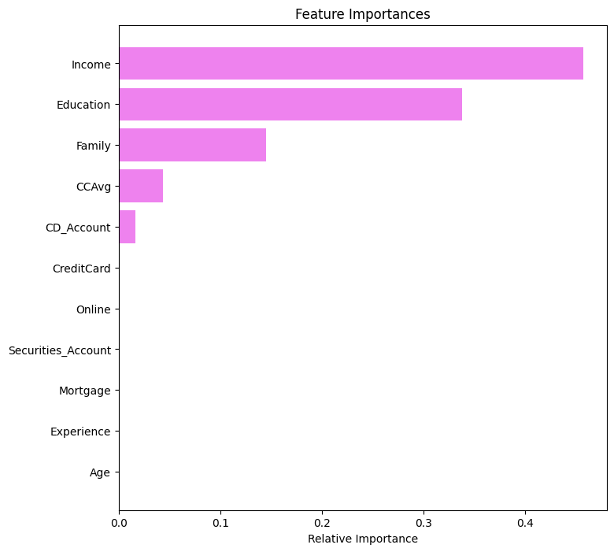

```python
# importance of features in the tree building
importances = dtree3.feature_importances_
indices = np.argsort(importances)

plt.figure(figsize=(8, 8))
plt.title("Feature Importances")
plt.barh(range(len(indices)), importances[indices], color="violet", align="center")
plt.yticks(range(len(indices)), [feature_names[i] for i in indices])
plt.xlabel("Relative Importance")
plt.show()
```

As shown in the figure above, the **top 3 important features are: Income level, Education level, and Family size.**

# Final Model Selection

**Predicting on a single data point**

```python
# choosing a data point
customer_details = X_test.iloc[:1, :]

# making a prediction for purchase/not purchase
loan_purchase_prediction = dtree3.predict(customer_details)

print(loan_purchase_prediction)
```

```
[0]
```

```python
# making a prediction for likelihood of purchase
loan_purchase_likelihood = dtree3.predict_proba(customer_details)

print(loan_purchase_likelihood[0, 1])
```

```
0.0
```

## Actionable Insights and Business Recommendations

**What recommendations would you suggest to the bank?**

- The bank can deploy this model to identify the potential customers who have a higher probability of purchasing the loan
- The Income level, Education level, and Family size customer attributes are the top three most significant in determining loan purchases, so the retail marketing department should devise campaigns focused on these attributes.
- Customers with a higher education level are more likely to purchase a loan, so marketing campaigns should be focused toward this customer segment.
- Customers with higher income levels (greater than $98,500 according to the decision tree rules) are more likely to purchase a loan, so this segment of customers should be targeted.
- Customers with larger family sizes are more likely to purchase a loan, so these segments should be targeted.
- CCAvg (average credit card spend per month in thousand dollars) was the fourth most significant customer attribute, so customers with higher credit card spending should be targeted more.
- CD_Account (whether or not a customer has a CD account) was the fifth most significant customer attribute, so customers with an existing CD account should be targeted as well.